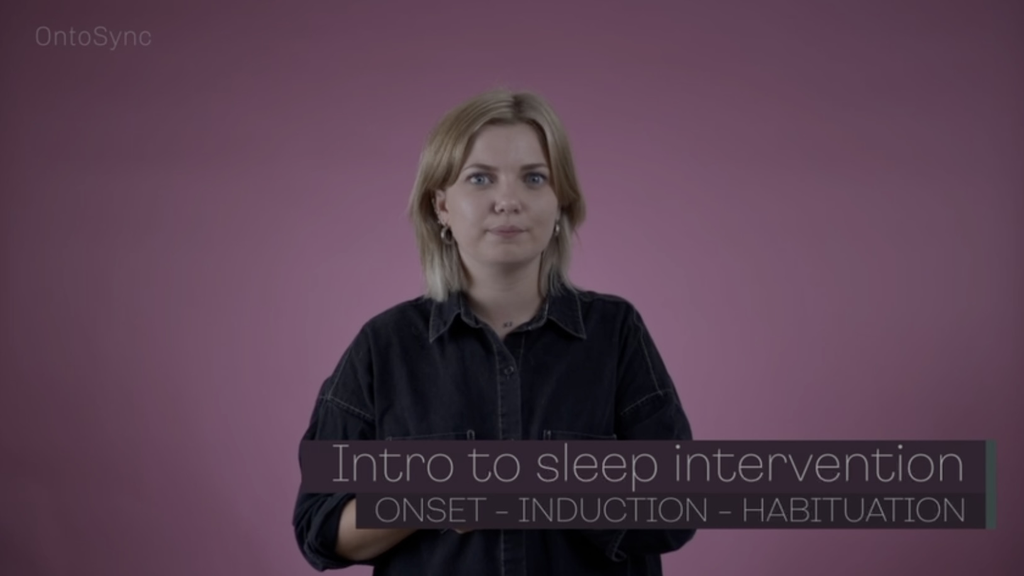

# Kirsty Hawkins

Kirsty Hawkins researches music cognition, specifically the management and organisation of musical information in working memory. Her PhD project is under the supervision of [Daniel Mullensiefen](https://www.gold.ac.uk/psychology/staff/mullensiefen/). Kirsty is developing a novel music-based measure for prioritisation, with the aim of using this to improve general working memory.

Beyond her Ph.D work, Kirsty has a number of part-time positions both in and outside of academia. Notably, OntoSync is a startup organisation rooted in cognitive psychology that Kirsty works closely with as the Research and Project Delivery Lead. Kirsty also works as a Research Officer for [PRS for Music](https://www.prsformusic.com/), ensuring music royalties are distributed to musicians timely and accurately. Kirsty uses these experiences as well as teaching roles inform her research.

## Education

**Goldsmiths, University of London**

Ph.D. Psychology | September 2021 - Present

M.Sc. Music Mind and Brain | September 2018 - September 2019

## Experience

**The Brilliant Club** | Tutor | October 2022 - Present

**OntoSync** | Research and Project Delivery Lead | July 2022 - Present

**Goldsmiths, UoL** | Associate Lecturer | Multivariate Statistics | October 2021 - Present

**PRS for Music** | Research Officer | September 2019 - Present